# SOP for Soil Color Measurement with Nix Pro

Edwin Rivas and D.E. Beaudette

2021-01-27

## Overview

The Nix Pro is useful for rapidly measuring soil color on prepared samples in a lab setting. Our testing suggests that moisture content and sample roughness can have a very large impact on the measured color and variations between repeat measurements.

## About the Device

The Nix Pro is a black diamond-shaped device with two light sources and a color sensor at the tip. The device is operated through a cellular device, or any device that can support the Nix Pro Color Sensor app and has bluetooth capabilities. It is charged through a micro-USB port. We recommend setting the standard illuminant to **D65**.

## Maintenance

The sensor and light sources are covered by windows that can be scratched or dirtied by the soil if not handled correctly. Use a soft bristled brush to clean the sensor and light windows frequently. Always have the sensor facing down and raised above your head when cleaning. Given no manual method to calibrate the Nix, every 10 samples, scan the white tile provided and ensure measurements aren’t drifting.

| sample | L | A | B |
| --- | --- | --- | --- |
| 1 | 90.0 | 0.2 | -0.6 |
| 2 | 89.6 | 0.4 | -0.9 |
| 3 | 89.6 | 0.4 | -0.8 |
| 4 | 89.7 | 0.3 | -0.8 |
| 5 | 89.8 | 0.3 | -0.8 |
| 6 | 89.8 | 0.3 | -0.7 |

The standard deviation of all measurements of the white reference tile should be less than 1 unit. .

```r
round(apply(x[, -1], 2, sd), 2)
```

```
##    L    A    B
## 0.15 0.08 0.10
```

The overall contrast (CIE2000 or *Δ**E*<sub>00</sub>) within these measurements should be less than 1.

```r
dE00 <- farver::compare_colour(
  x[, -1],
  from_space = 'lab',
  to_space = 'lab',
  white_from = 'D65',
  white_to = 'D65',
  method = 'CIE2000'
)

# dE00
round(range(dE00), 2)
```

```
## [1] 0.00 0.48
```

## General Instructions for Preparing a Soil Sample and Operating the Device

1. Clean all equipment utilized (plastic capsules, pestle, plastic dish, and sieve) with water and sponge. Dry equipment thoroughly
2. Choose ped(s) from the sample box large enough to nearly fill the plastic capsules
3. Break ped(s) into smaller pieces (if necessary) by putting it in between a paper towel and crushing it with the pestle
4. Transfer the ped into the 2mm sieve and further crush ped by applying pressure along the sides of the sieve, avoid applying pressure on the mesh
5. Crush soil further within the pan of the 2mm sieve, using only the weight of the pestle
6. Transfer sieved soil into the 500 micrometer sieve
7. Swirl sieve to separate
8. Transfer soil <500 micrometer onto the plastic dish
9. Transfer soil from dish to the capsule overfilling it
10. Carefully scrape excess off to leaving it flat and filled to capacity
11. Carefully position the Nix on top of the sample ensuring it does not go too deep
12. Run a test to see if there is light escaping
13. Measure the color several times
14. Gently pull away Nix with sensor facing down
15. Carefully brush away residue left on the Nix by brushing it away from the sensor
16. Wipe equipment with a paper towel in between samples
17. Re-clean equipment with water in between boxes

## Notes

If soils within the same box vary in color drastically, wash the equipment in between the horizons.

## Lab Sheet Notes

Create a “lab sheet” before scanning a batch of samples. Each lab sheet should contain the following:

- peiid: pedon record ID
- phiid: pedon horizon record ID
- user site ID
- user pedon ID
- horizon depths and designations
- sample (serial) number, 1 to number of rows in the lab sheet
- L, A, B entries

Sample (serial) numbers are specific to a lab sheet. Save scans to a folder named after the lab sheet, with each scan labeled using the serial number. Record CIE L, A, and B values on the paper copy of the lab sheet as a backup. Multiple scans of the same sample should use the same serial number (these values can be averaged later). When completed, a lab sheet can be converted into a final electronic copy that includes NASIS IDs and CIE LAB values for further analysis. Retain paper copies just in case.

## Converting from LAB Color Space to Munsell Chips

Note that color space conversion depends on specification of the correct illuminant. The default for the Nix Pro (may?) be D50. Be sure to adjust as needed.

The function `rgb2munsell()` will lookup the closest Munsell chip using sRGB (D65 illuminant) coordinates.

```r
# load required libraries
library(aqp)
library(sharpshootR)
library(Gmedian)
library(farver)

# load CSV files
x <- read.csv('Pedon-color-data.csv', stringsAsFactors = FALSE, na.strings = '-')

# check the lab sheet with LAB values as measured by the Nix Pro
knitr::kable(head(x), row.names = FALSE)
```

| peiid | phiid | site_id | pedon_id | hzdept | hzdepb | hzname | serial | X | L | A | B |
| --- | --- | --- | --- | --- | --- | --- | --- | --- | --- | --- | --- |
| 351722 | 1567731 | 07CA630RJV150 | 07RJV150N | 0 | 10 | A | 1 | NA | 47.6 | 11.2 | 21.9 |
| 351722 | 1567732 | 07CA630RJV150 | 07RJV150N | 10 | 28 | BA | 2 | NA | 44.6 | 13.6 | 22.1 |
| 351722 | 1567733 | 07CA630RJV150 | 07RJV150N | 28 | 43 | Bt1 | 3 | NA | 50.3 | 14.6 | 24.6 |
| 351722 | 1567734 | 07CA630RJV150 | 07RJV150N | 43 | 58 | Bt2 | 4 | NA | 43.2 | 13.1 | 22.6 |
| 351722 | 1567735 | 07CA630RJV150 | 07RJV150N | 58 | 69 | Bt3 | 5 | NA | 48.9 | 14.9 | 25.1 |
| 351722 | 1567736 | 07CA630RJV150 | 07RJV150N | 69 | 102 | Bt4 | 6 | NA | 42.6 | 12.3 | 21.1 |

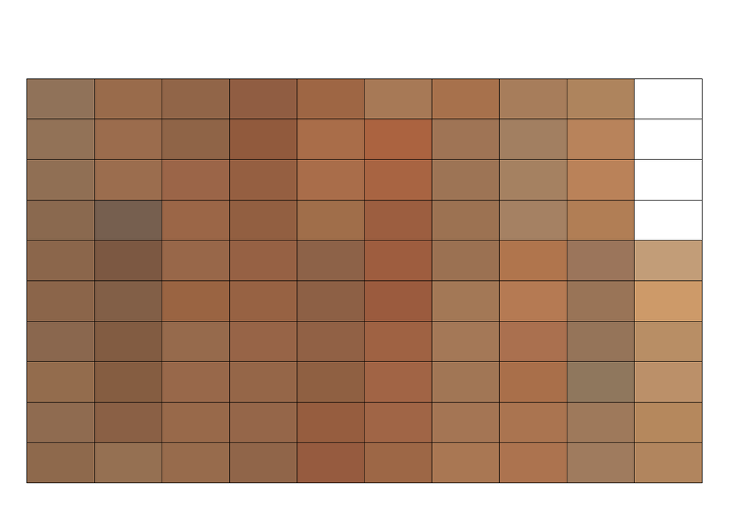

```r
# convert to sRGB
# result is in the interval of 0-255
x.srgb <- convert_colour(x[, c('L', 'A', 'B')], from = 'lab', to = 'rgb', white_from = 'D65', white_to = 'D65')

# remove NA
x.srgb <- na.omit(x.srgb)

# convert to hex notation
# set max color value for correct encoding
x.cols <- rgb(x.srgb, maxColorValue = 255)

# check graphically
previewColors(x.cols)
```

Estimate proportions of colors, as grouped into 8 classes via partitioning around medoids (`cluster::pam`), in LAB coordinates.

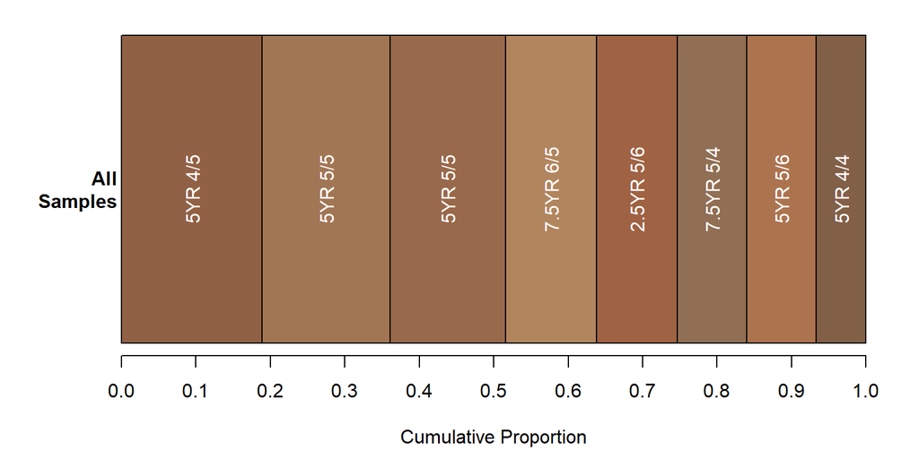

```r
# prepare a fake SoilProfileCollection object
s <- data.frame(
  group = 'All\nSamples',
  id = seq_along(x.cols),
  top = 0,
  bottom = 1,
  soil_color = x.cols,
  stringsAsFactors = FALSE
)

depths(s) <- id ~ top + bottom
site(s) <- ~ group

# aggregate color
a <- aggregateColor(s, groups='group', col='soil_color', k = 8)

# plot
par(mar=c(4.5,4,1,1))
aggregateColorPlot(a, label.cex = 1)
```

Evaluate marginal percentiles of L, A, B, and geometric (L1) median.

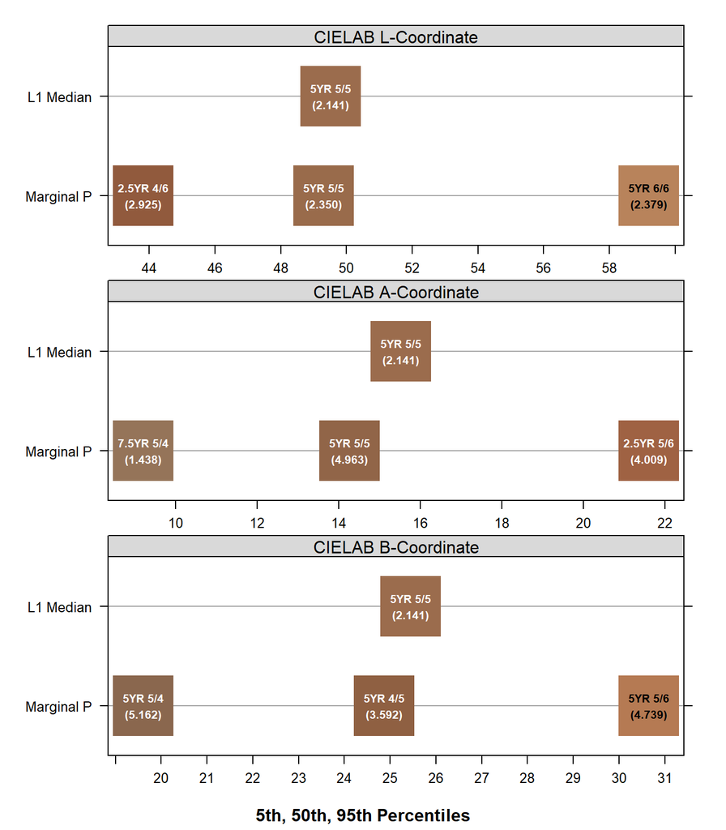

```r
# quantiles
cq <- colorQuantiles(x.cols)
plotColorQuantiles(cq)
```

Check all LAB → Munsell conversions.

```r
# convert to closest Munsell chip from sRGB
# function expects sRGB in the range of 0-1
x.munsell <- rgb2munsell(x.srgb / 255)

# Results
knitr::kable(x.munsell, row.names = FALSE)
```

| hue | value | chroma | sigma |
| --- | --- | --- | --- |
| 7.5YR | 5 | 4 | 4.2347597 |
| 5YR | 4 | 4 | 3.1903521 |
| 5YR | 5 | 5 | 1.3459729 |
| 5YR | 4 | 4 | 2.1599962 |
| 5YR | 5 | 5 | 2.6830186 |
| 5YR | 4 | 4 | 1.5870601 |
| 5YR | 4 | 4 | 5.0181185 |
| 7.5YR | 5 | 4 | 3.0923145 |
| 5YR | 5 | 5 | 3.3682552 |
| 5YR | 5 | 5 | 1.1835907 |
| 5YR | 5 | 6 | 1.3058463 |
| 5YR | 6 | 6 | 4.1259992 |
| 7.5YR | 7 | 6 | 3.3441187 |
| 5YR | 5 | 5 | 2.1995578 |
| 5YR | 5 | 6 | 3.5306204 |
| 5YR | 5 | 6 | 4.2761868 |
| 5YR | 5 | 5 | 5.0401219 |
| 5YR | 5 | 5 | 1.5988847 |
| 5YR | 5 | 5 | 4.7890506 |
| 5YR | 4 | 5 | 3.6301903 |
| 5YR | 4 | 5 | 4.0694331 |
| 2.5YR | 4 | 6 | 3.0656773 |
| 5YR | 5 | 6 | 1.2821194 |
| 7.5YR | 6 | 5 | 1.4496764 |
| 7.5YR | 6 | 5 | 2.7689391 |
| 5YR | 5 | 5 | 2.5857282 |
| 5YR | 5 | 5 | 1.8711326 |
| 5YR | 5 | 6 | 2.6418890 |
| 5YR | 5 | 6 | 1.9989760 |
| 5YR | 5 | 6 | 1.7927397 |

[output cut: 66 more lines]